# Obtaining Data

**Module 02** GESIS Fall Seminar “Introduction to Computational Social Science”

Johannes B. Gruber

GESIS

John McLevey

University of Waterloo

# Introduction

## Schedule: GESIS Fall Seminar in Computational Social Science

Course Schedule

| time | Session |
| --- | --- |
| Day 1 | Introduction to Computational Social Science |
| **Day 2** | **Obtaining Data** |
| Day 3 | Computational Network Analysis |
| Day 4 | Computational Text Analysis |
| Day 5 | Large Language Models in the Social Sciences |

## The Plan for Today

- Learn what Web Scraping is
- Get an understanding of the web
- Learn how to identify patterns you can use for scraping
- Get an overview of relevant tools
- Learn about legal and ethical concerns (and myths)

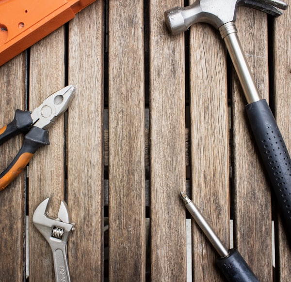

[Louis Hansel](https://unsplash.com/@louishansel) via unsplash.com

## Found vs Designed Data

### Designed Data

- collected for research
- full control of shape and form
- problems of validity due to social desirability and imperfect estimation problems

### Found Data

- traces of human behaviour
- comes in all shapes and forms
- problems of validity as not representative and incomplete access

# What is Web Scraping & should You Learn/Use it?

## What is Web Scraping

- Used when other means are unavailable
- Scrape the (unstructured) Data
- A web-scraper is a program (or robot) that:
  - goes to a web page
  - downloads its content
  - extracts data from the content
  - then saves the data to a file or a database
- Unfortunately no one-size-fits-all solution
  - Lots of different techniques, tools, tricks
  - Websites change (some more frequently than others)
  - Some websites make it hard for you (by accident or on purpose!)

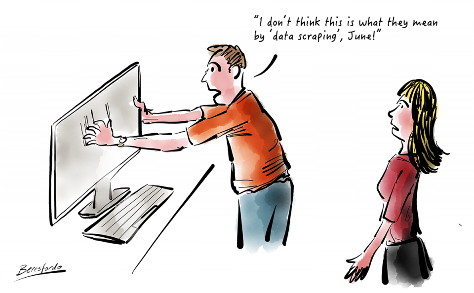

Image Source: daveberesford.co.uk

## What is Web Scraping

- Used when other means are unavailable
- Scrape the (unstructured) Data
- A web-scraper is a program (or robot) that:
  - goes to a web page
  - downloads its content
  - extracts data from the content
  - then saves the data to a file or a database
- Unfortunately no one-size-fits-all solution
  - Lots of different techniques, tools, tricks
  - Websites change (some more frequently than others)
  - Some websites make it hard for you (by accident or on purpose!)

[figure not shown]

## What is Web Scraping

- Used when other means are unavailable
- Scrape the (unstructured) Data
- A web-scraper is a program (or robot) that:
  - goes to a web page
  - downloads its content
  - extracts data from the content
  - then saves the data to a file or a database
- Unfortunately no one-size-fits-all solution
  - Lots of different techniques, tools, tricks
  - Websites change (some more frequently than others)
  - Some websites make it hard for you (by accident or on purpose!)

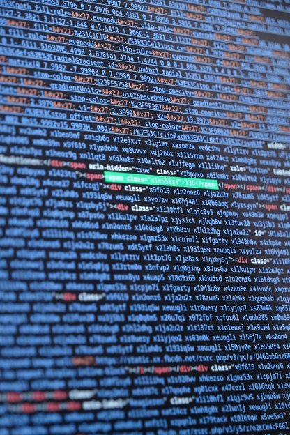

## Web Scraping: A Three-Step Process

1. Send an HTTP request to the webpage -> server responds to the request by returning (HTML) content
2. Parse the HTML content -> extract the information you want from the nested structure of (HTML) code
3. Wrangle the data into a useful format

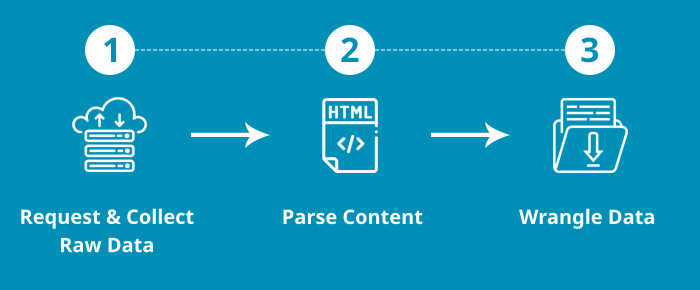

Original Image Source: prowebscraper.com

## Why Should You Learn Web Scraping?

- The internet is a data gold mine!
- Data were not created for research, but are often traces of what people are *actually* doing on the internet
- Reproducible and renewable data collection (e.g., rehydrate data that is copyrighted)
- Web Scraping let’s you automate data retrieval (as opposed to using tedious copy & past on some web site)
- It’s one of the most fun tasks to learn R and programming!
  - It’s engaging and satisfying to find repeating patterns that you can employ to structure data (every website becomes a little puzzle)
  - It touches on many important computational skills
  - The return is good data to further your career (unlike sudokus or video games)

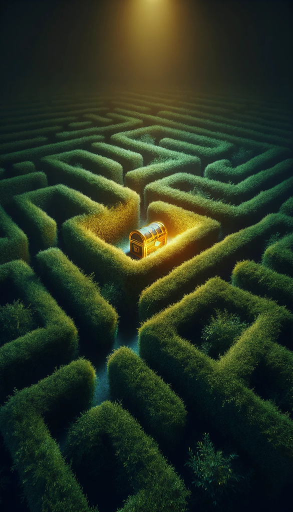

# What are HTML and CSS

## What is HTML

- HTML (HyperText Markup Language) is the standard markup language for documents designed to be displayed in a web browser
- Contains the raw data (text, URLs to pictures and videos) plus defines the layout and some of the styling of text

[figure not shown]

Image Source: [Wikipedia.org](https://en.wikipedia.org/wiki/HTML_element)

## Example: Simple

Code:

```
<!DOCTYPE html>
<html>
<head>
    <title>My Simple HTML Page</title>
</head>
<body>
    <p>This is the body of the text.</p>
</body>
</html>
```

Browser View:

[figure not shown]

## Example: With headline and author

Code:

```
<!DOCTYPE html>
<html>
<head>
    <title>My Simple HTML Page</title>
</head>
<body>
    <h1>My Headline</h1>
    <p class="author" href="https://www.johannesbgruber.eu/">Me</p>
    <p>This is the body of the text.</p>
</body>
</html>
```

Browser View:

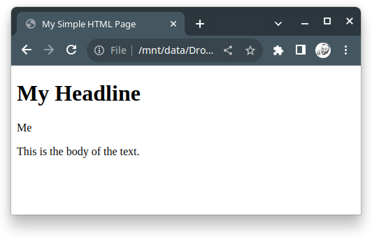

## Example: With some data

Code:

```html
<!DOCTYPE html>
<html>
<head>
    <title>My Simple HTML Page</title>
</head>
<body>
    <h1>My Headline</h1>
    <p class="author">Me</p>
    <p>This is the body of the text.</p>
    <p>Consider this data:</p>
    <table>
        <tr>
            <th>Name</th>
            <th>Age</th>
        </tr>
        <tr>
            <td>John</td>
            <td>25</td>
        </tr>
        <tr>
            <td>Mary</td>
            <td>26</td>
        </tr>
    </table>
</body>
</html>
```

Browser View:

[figure not shown]

## Example: With an image

Code:

```
<!DOCTYPE html>
<html>
<head>
    <title>My Simple HTML Page</title>
</head>
<body>
    <h1>My Headline</h1>
    <p class="author">Me</p>
    <p>This is the body of the text.</p>
    <p>Consider this image:</p>
    <img src="https://upload.wikimedia.org/wikipedia/commons/thumb/0/0c/About_The_Dog.jpg/640px-About_The_Dog.jpg" alt="About The Dog."></img>
</body>
</html>
```

Browser View:

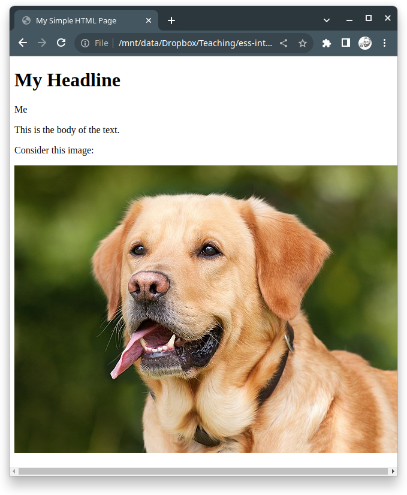

## Example: With a link

Code:

```
<!DOCTYPE html>
<html>
<head>
    <title>My Simple HTML Page</title>
</head>
<body>
    <h1>My Headline</h1>
    <a href="https://www.johannesbgruber.eu/">
      <p class="author">Me</p>
    </a>
    <p>This is the body of the text.</p>
</body>
</html>
```

Browser View:

[figure not shown]

## What is CSS

- CSS (Cascading Style Sheets) is very often used in addition to HTML to control the presentation of a document
- Designed to enable the separation of *content* from things concerning the *look*, such as layout, colours, and fonts.
- The reason it is interesting for web scraping is that **certain information often get the same styling**

## Example: CSS

HTML:

```
<!DOCTYPE html>
<html>
<head>
    <title>My Simple HTML Page</title>
    <link rel="stylesheet" type="text/css" href="example.css">
</head>
<body>
  <h1 class="headline">My Headline</h1>
  <p class="author">Me</p>
  <div class="content">
    <p>This is the body of the text.</p>
    <img src="https://upload.wikimedia.org/wikipedia/commons/thumb/0/0c/About_The_Dog.jpg/640px-About_The_Dog.jpg" alt="About The Dog.">
    <p>Consider this data:</p>
    <table>
      <tr class="top-row">
          <th>Name</th>
          <th>Age</th>
      </tr>
      <tr>
          <td>John</td>
          <td>25</td>
      </tr>
      <tr>
          <td>Mary</td>
          <td>26</td>
      </tr>
    </table>
  </div>
</body>
</body>
</html>
```

CSS:

```css
/* CSS file */

.headline {
  color: red;
}

.author {
  color: grey;
  font-style: italic;
  font-weight: bold;
}

.top-row {
  background-color: lightgrey;
}

.content img {
  border: 2px solid black;
}

table, th, td {
  border: 1px solid black;
}
```

Browser View:

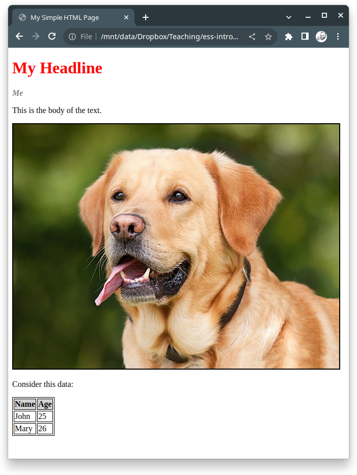

# HTML and CSS in Web Scraping

## Using HTML tags:

You can select HTML elements by their tags

```r
library(rvest)
read_html("data/example.html") |>  # retrieve content
  html_elements("p") |>                    # select content via css selector
  html_text2()                             # extract data you want
```

```
[1] "Me"                            "This is the body of the text."
[3] "Consider this image:"          "Consider this data:"
```

- to select them, **tags** are written without the `<>`
- in theory, arbitrary tags are possible, but commonly people use `<p>` (paragraph), `<br>` (line break), `<h1>`, `<h2>`, `<h3>`, … (first, second, third, … level headline), `<b>` (bold), `<i>` (italic), `<img>` (image), `<a>` (hyperlink), and a couple more.

## Using attributes

You can select elements by an attribute, including the class:

```r
read_html("data/example.html") |>
  html_element("[class=\"headline\"]") |>
  html_text()
```

```
[1] "My Headline"
```

For `class`, there is also a shorthand:

```r
read_html("data/example.html") |>
  html_element(".headline") |>
  html_text()
```

```
[1] "My Headline"
```

Another important shorthand is `#`, which selects the `id` attribute:

```r
read_html("data/example.html") |>
  html_element("#table-1") |>
  html_table()                     # html_table tries to re-assemble tables
```

```
# A tibble: 2 × 2
  Name    Age
  <chr> <int>
1 John     25
2 Mary     26
```

## Extracting attributes

Instead of selecting by attribute, you can also extract one or all attributes:

```r
read_html("data/example.html") |>
  html_elements("a") |>
  html_attr("href")
```

```
[1] "https://www.johannesbgruber.eu/"   "https://en.wikipedia.org/wiki/Dog"
```

```r
read_html("data/example.html") |>
  html_elements("a") |>
  html_attrs()
```

```
[[1]]
                             href
"https://www.johannesbgruber.eu/"

[[2]]
                               href
"https://en.wikipedia.org/wiki/Dog"
```

## Chaining selectors

If there is more than one element that fits your selector, but you only want one of them, see if you can make your selection more specific by chaining selectors with `>` (for the immediate next one) or an empty space (for any children of an element):

```r
read_html("data/example.html") |>
  html_elements(".author>a") |>
  html_attr("href")
```

```
[1] "https://www.johannesbgruber.eu/"
```

```r
read_html("data/example.html") |>
  html_elements(".author a") |>
  html_attr("href")
```

```
[1] "https://www.johannesbgruber.eu/"
```

Tip: there is also no rule against doing this instead:

```r
read_html("data/example.html") |>
  html_elements(".author") |>
  html_elements("a") |>
  html_attr("href")
```

```
[1] "https://www.johannesbgruber.eu/"
```

## Common Selectors

There are quite a lot of [CSS selectors](https://www.w3schools.com/cssref/css_selectors.asp), but often you can stick to just a few:

| selector | example | Selects |
| --- | --- | --- |
| element/tag | `table` | **all** `<table>` elements |
| class | `.someTable` | **all** elements with `class="someTable"` |
| id | `#table-1` | **unique** element with `id="table-1"` |
| element.class | `tr.headerRow` | **all** `<tr>` elements with the `headerRow` class |
| class1.class2 | `.someTable.blue` | **all** elements with the `someTable` AND `blue` class |
| class1 > tag | `.table-1 > tr` | **all** elements with `tr` with `.table-1` as parent |
| class1 + tag | `.top-row + tr` | **first** elements with `tr` following `.top-row` |

## Family Relations

Each html tag can contain other tags. To keep track of the relations we speak of ancestors, descendants, parents, children and siblings.

```html
<book>
  <chapter>
    <section>
      <subsection>
        This is a subsection.
      </subsection>
      <subsection>
        This is another subsection.
      </subsection>
    </section>
    <section>
      This is a section.
    </section>
  </chapter>
  <chapter>
    <section>
      This is a section.
    </section>
    <section>
      This is a section.
    </section>
  </chapter>
  <chapter>
    This is a chapter without sections.
  </chapter>
</book>
```

# Scraping Static Web Pages

## Example: World Happiness Report

### Use your Browser to Scout

[figure not shown]

[figure not shown]

[figure not shown]

### Use your Browser’s `Inspect` tool

[figure not shown]

*Note: Might not be available on all browsers; use Chromium-based or Firefox or enable in Safari.*

### Use `rvest` to scrape

```r
library(rvest)
library(tidyverse)

# 1. Request & collect raw html
html <- read_html("https://en.wikipedia.org/w/index.php?title=World_Happiness_Report&oldid=1165407285")

# 2. Parse
happy_table <- html |>
  html_elements(".wikitable") |> # select the right element
  html_table() |>                # special function for tables
  pluck(3)                       # select the third table

# 3. No wrangling necessary
happy_table
```

```
# A tibble: 153 × 9
   `Overall rank` `Country or region` Score `GDP per capita` `Social support`
            <int> <chr>               <dbl>            <dbl>            <dbl>
 1              1 Finland              7.81             1.28             1.5
 2              2 Denmark              7.65             1.33             1.50
 3              3 Switzerland          7.56             1.39             1.47
 4              4 Iceland              7.50             1.33             1.55
 5              5 Norway               7.49             1.42             1.50
 6              6 Netherlands          7.45             1.34             1.46
 7              7 Sweden               7.35             1.32             1.43
 8              8 New Zealand          7.3              1.24             1.49
 9              9 Austria              7.29             1.32             1.44
10             10 Luxembourg           7.24             1.54             1.39
# ℹ 143 more rows
# ℹ 4 more variables: `Healthy life expectancy` <dbl>,
#   `Freedom to make life choices` <dbl>, Generosity <dbl>,
#   `Perceptions of corruption` <dbl>
```

```r
## Plot relationship wealth and life expectancy
ggplot(happy_table, aes(x = `GDP per capita`, y = `Healthy life expectancy`)) +
  geom_point() +
  geom_smooth(method = 'lm')
```

[figure not shown]

## Example: UK prime ministers on Wikipedia

### Use your Browser to Scout

[figure not shown]

### Use `rvest` to scrape

```r
# 1. Request & collect raw html
html <- read_html("https://en.wikipedia.org/w/index.php?title=List_of_prime_ministers_of_the_United_Kingdom&oldid=1166167337") # I'm using an older version of the site since some just changed it

# 2. Parse
pm_table <- html |>
  html_element(".wikitable:contains('List of prime ministers')") |>
  html_table() |>
  as_tibble(.name_repair = "unique") |>
  filter(!duplicated(`Prime ministerOffice(Lifespan)`))

# 3. No wrangling necessary
pm_table
```

```
# A tibble: 75 × 11
   Portrait...1 Portrait...2 Prime ministerOffice(Lifespa…¹ `Term of office...4`
   <chr>        <chr>        <chr>                          <chr>
 1 "Portrait"   "Portrait"   Prime ministerOffice(Lifespan) start
 2 ""           ""           Robert Walpole[27]MP for King… 3 April1721
 3 ""           ""           Spencer Compton[28]1st Earl o… 16 February1742
 4 ""           ""           Henry Pelham[29]MP for Sussex… 27 August1743
 5 ""           ""           Thomas Pelham-Holles[30]1st D… 16 March1754
 6 ""           ""           William Cavendish[31]4th Duke… 16 November1756
 7 ""           ""           Thomas Pelham-Holles[32]1st D… 29 June1757
 8 ""           ""           John Stuart[33]3rd Earl of Bu… 26 May1762
 9 ""           ""           George Grenville[34]MP for Bu… 16 April1763
10 ""           ""           Charles Watson-Wentworth[35]2… 13 July1765
# ℹ 65 more rows
# ℹ abbreviated name: ¹`Prime ministerOffice(Lifespan)`
# ℹ 7 more variables: `Term of office...5` <chr>, `Term of office...6` <chr>,
#   `Mandate[a]` <chr>, `Ministerial offices held as prime minister` <chr>,
#   Party <chr>, Government <chr>, MonarchReign <chr>
```

```html
<td rowspan="4">
  <span class="anchor" id="18th_century"></span>
   <b>
     <a href="/wiki/Robert_Walpole" title="Robert Walpole">Robert Walpole</a>
   </b>
   <sup id="cite_ref-FOOTNOTEEccleshallWalker20021,_5EnglefieldSeatonWhite19951–5PrydeGreenwayPorterRoy199645–46_28-0" class="reference">
     <a href="#cite_note-FOOTNOTEEccleshallWalker20021,_5EnglefieldSeatonWhite19951–5PrydeGreenwayPorterRoy199645–46-28">[27]</a>
   </sup>
   <br>
   <span style="font-size:85%;">MP for <a href="/wiki/King%27s_Lynn_(UK_Parliament_constituency)" title="King's Lynn (UK Parliament constituency)">King's Lynn</a>
   <br>(1676–1745)
  </span>
</td>
```

```r
links <- html |>
  html_elements(".wikitable:contains('List of prime ministers') b a") |>
  html_attr("href")
title <- html |>
  html_elements(".wikitable:contains('List of prime ministers') b a") |>
  html_text()
tibble(name = title, link = links)
```

```
# A tibble: 90 × 2
   name                 link
   <chr>                <chr>
 1 Robert Walpole       /wiki/Robert_Walpole
 2 George I             /wiki/George_I_of_Great_Britain
 3 George II            /wiki/George_II_of_Great_Britain
 4 Spencer Compton      /wiki/Spencer_Compton,_1st_Earl_of_Wilmington
 5 Henry Pelham         /wiki/Henry_Pelham
 6 Thomas Pelham-Holles /wiki/Thomas_Pelham-Holles,_1st_Duke_of_Newcastle
 7 William Cavendish    /wiki/William_Cavendish,_4th_Duke_of_Devonshire
 8 Thomas Pelham-Holles /wiki/Thomas_Pelham-Holles,_1st_Duke_of_Newcastle
 9 George III           /wiki/George_III
10 John Stuart          /wiki/John_Stuart,_3rd_Earl_of_Bute
# ℹ 80 more rows
```

Note: these are relative links that need to be combined with *https://en.wikipedia.org/* to work

# Other Techniques

## APIs

- An Application Programming Interface (API) is a way for two computer programs to speak to each other
- Commonly used to distribute data or do many other things (e.g., the defunct Twitter and Facebook APIs, NYT and Guardian APIs, MediaCloud API)
- Good way to access APIs: `httr2`

### API example: Guardian API

If you want to follow along:

- get your key: https://bonobo.capi.gutools.co.uk/register/developer
- look at documentation: https://open-platform.theguardian.com/documentation/

```r
library(httr2)
library(tidyverse, warn.conflicts = FALSE)
req <- request("https://content.guardianapis.com") |>  # start the request with the base URL
  req_url_path("search") |>                            # navigate to the endpoint you want to access
  req_method("GET") |>                                 # specify the method
  req_timeout(seconds = 60) |>                         # how long to wait for a response
  req_headers("User-Agent" = "httr2 guardian test") |> # specify request headers
  # req_body_json() |>                                 # since this is a GET request the body stays empty
  req_url_query(                                       # instead the query is added to the URL
    q = "parliament AND debate",
    "show-blocks" = "all"
  ) |>
  req_url_query(                                       # in this case, the API key is also added to the query
    "api-key" = "d187828f-9c6a-4c29-afd4-dbd43e116965"             # but httr2 also has req_auth_* functions for other
  )                                                    # authentication procedures
print(req)
```

```
<httr2_request>
GET https://content.guardianapis.com/search?q=parliament%20AND%20debate&show-blocks=all&api-key=d187828f-9c6a-4c29-afd4-dbd43e116965
Headers:
* User-Agent: "httr2 guardian test"
Body: empty
Options:
* timeout_ms    : 60000
* connecttimeout: 0
```

Nothing is done until you perform the request:

```r
resp <- req |>
  req_perform()
```

Then you need to parse the response:

```r
parse_response <- function(resp) {
  # make sure response is valid
  if (resp_content_type(resp) != "application/json") {
    stop("Request was not succesful!")
  }

  # extract articles
  results <- resp_body_json(resp) |>
    pluck("response", "results")

  # parse into data.frame
  map(results, function(res) {
    tibble(
      id = res$id,
      type = res$type,
      time = lubridate::ymd_hms(res$webPublicationDate),
      headline = res$webTitle,
      text = rvest::read_html(pluck(res, "blocks", "body", 1, "bodyHtml")) |> rvest::html_text2()
    )
  }) |>
    bind_rows()

}
parse_response(resp)
```

```
# A tibble: 10 × 5
   id                                   type  time                headline text
   <chr>                                <chr> <dttm>              <chr>    <chr>
 1 australia-news/2025/aug/08/dissent-… arti… 2025-08-07 22:08:45 Dissent… "Sim…
 2 world/2024/dec/10/queensland-parlia… arti… 2024-12-10 03:48:32 Queensl… "The…
 3 australia-news/2025/aug/25/coalitio… arti… 2025-08-24 15:00:36 Coaliti… "The…
 4 politics/2025/jul/03/welfare-reform… arti… 2025-07-03 17:05:16 Welfare… "The…
 5 society/2025/may/13/assisted-dying-… arti… 2025-05-13 15:55:00 Give te… "Sco…
 6 world/2025/jun/25/irans-parliament-… arti… 2025-06-25 17:27:30 Iran’s … "Ira…
 7 world/2025/aug/05/germany-retiremen… arti… 2025-08-05 04:00:41 Pension… "The…
 8 world/2025/jan/31/german-parliament… arti… 2025-01-31 17:19:30 German … "The…
 9 politics/2025/sep/01/forget-orwells… arti… 2025-09-01 17:37:13 Forget … "Wha…
10 uk-news/2025/apr/12/uk-mps-tweet-to… arti… 2025-04-12 14:44:41 UK MPs … "For…
```

## Special Requests

- Some websites limit requests
- When you run `read_html` from `rvest`, it uses a default request that fits most of the time, but not always:

```r
html <- read_html("https://www.icahdq.org/mpage/ICA23-Program")
```

```
Error in open.connection(x, "rb"): cannot open the connection
```

To interpret HTTP errors, you can use this handy function:

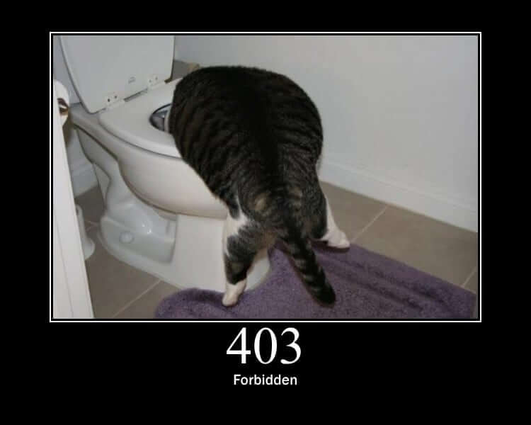

```r
error_cat <- function(error) {
  link <- paste0("https://http.cat/images/", error, ".jpg")
  knitr::include_graphics(link)
}
error_cat(403)
```

So what to do next?

- Scope the Network tab
- Translate Curl
- Build request in R

## Translate the `cURL` call

```r
curl_translate("curl 'https://whova.com/xems/apis/event_webpage/agenda/public/get_agendas/?event_id=JcQAdK91J0qLUtNxOYUVWFMTUuQgIg3Xj6VIeeyXVR4%3D' \
  -H 'Accept: application/json, text/plain, */*' \
  -H 'Accept-Language: en-GB,en-US;q=0.9,en;q=0.8' \
  -H 'Cache-Control: no-cache' \
  -H 'Connection: keep-alive' \
  -H 'Pragma: no-cache' \
  -H 'Referer: https://whova.com/embedded/event/JcQAdK91J0qLUtNxOYUVWFMTUuQgIg3Xj6VIeeyXVR4%3D/' \
  -H 'Sec-Fetch-Dest: empty' \
  -H 'Sec-Fetch-Mode: cors' \
  -H 'Sec-Fetch-Site: same-origin' \
  -H 'User-Agent: Mozilla/5.0 (X11; Linux x86_64) AppleWebKit/537.36 (KHTML, like Gecko) Chrome/115.0.0.0 Safari/537.36' \
  -H 'sec-ch-ua: \"Chromium\";v=\"115\", \"Not/A)Brand\";v=\"99\"' \
  -H 'sec-ch-ua-mobile: ?0' \
  -H 'sec-ch-ua-platform: \"Linux\"' \
  --compressed")
```

```
request("https://whova.com/xems/apis/event_webpage/agenda/public/get_agendas/") |>
  req_url_query(
    event_id = "JcQAdK91J0qLUtNxOYUVWFMTUuQgIg3Xj6VIeeyXVR4=",
  ) |>
  req_headers(
    Accept = "application/json, text/plain, */*",
    `Accept-Language` = "en-GB,en-US;q=0.9,en;q=0.8",
    `Cache-Control` = "no-cache",
    `User-Agent` = "Mozilla/5.0 (X11; Linux x86_64) AppleWebKit/537.36 (KHTML, like Gecko) Chrome/115.0.0.0 Safari/537.36",
  ) |>
  req_perform()
```

## Make request in R

```r
ica_programme_data <- request("https://whova.com/xems/apis/event_webpage/agenda/public/get_agendas/?event_id=JcQAdK91J0qLUtNxOYUVWFMTUuQgIg3Xj6VIeeyXVR4%3D") |>
  req_headers(
    Accept = "application/json, text/plain, */*",
    `Accept-Language` = "en-GB,en-US;q=0.9,en;q=0.8",
    `Cache-Control` = "no-cache",
    Connection = "keep-alive",
    Pragma = "no-cache",
    Referer = "https://whova.com/embedded/event/JcQAdK91J0qLUtNxOYUVWFMTUuQgIg3Xj6VIeeyXVR4%3D/",
    `Sec-Fetch-Dest` = "empty",
    `Sec-Fetch-Mode` = "cors",
    `Sec-Fetch-Site` = "same-origin",
    `User-Agent` = "Mozilla/5.0 (X11; Linux x86_64) AppleWebKit/537.36 (KHTML, like Gecko) Chrome/115.0.0.0 Safari/537.36",
    `sec-ch-ua` = "\"Chromium\";v=115\", \"Not/A)Brand\";v=\"99",
    `sec-ch-ua-mobile` = "?0",
    `sec-ch-ua-platform` = "\"Linux\"",
  ) |>
  req_perform() |>
  resp_body_json()
```

```r
object.size(ica_programme_data) |>
  format("MB")
```

```
[1] "6.7 Mb"
```

It worked!

## Special Requests: Behind Paywall

Let’s get this [cool data journalism article](https://www.zeit.de/mobilitaet/2024-04/deutschlandticket-klimaschutz-oeffentliche-verkehrsmittel-autos-verkehrswende).

```r
html <- read_html("https://www.zeit.de/mobilitaet/2024-04/deutschlandticket-klimaschutz-oeffentliche-verkehrsmittel-autos-verkehrswende")
html |>
  html_elements(".article-body p") |>
  html_text2()
```

```
[1] "Ganz Deutschland fährt Bahn. So fühlte sich das im Sommer 2022 zumindest an, als das 9-Euro-Ticket für drei Monate für überfüllte Züge sorgte. Die Bundesregierung und viele Menschen zeigten sich begeistert: So leicht war es also, Bürgerinnen und Bürger für die umweltfreundlichen öffentlichen Ve…
[2] "Aber als die Bundesregierung den Nachfolger vorstellte, waren viele enttäuscht. 49 Euro monatlich kostet das Deutschlandticket und ist nur im Abo erhältlich. Euphorisch war nur noch die Bundesregierung. Doch jetzt, ein Jahr nach dem Start, kann man sagen: zu Recht. Zumindest, was die Fahrgastza…
```

🤔 Wait, that’s only the first two paragraphs!

## Special Requests: Behind Paywall Cookies!

```r
library(cookiemonster)
add_cookies("cookies.txt")
```

```r
html <- request("https://www.zeit.de/mobilitaet/2024-04/deutschlandticket-klimaschutz-oeffentliche-verkehrsmittel-autos-verkehrswende") |> # start a request
  req_options(cookie = get_cookies("zeit.de", as = "string")) |> # add cookies to be sent with it
  req_perform() |>
  resp_body_html() # extract html from response

html |>
  html_elements(".article-body p") |>
  html_text2()
```

## Interactive Website

```r
static <- read_html("https://www.google.de/maps/dir/Armadale+St,+Glasgow,+UK/Lilybank+House,+Glasgow,+UK/@55.8626667,-4.2712892,14z/data=!3m1!4b1!4m14!4m13!1m5!1m1!1s0x48884155c8eadf03:0x8f0f8905398fcf2!2m2!1d-4.2163615!2d55.8616765!1m5!1m1!1s0x488845cddf3cffdb:0x7648f9416130bcd5!2m2!1d-4.2904601!2d55.8740368!3e0?entry=ttu")
static |>
  html_elements(".Fk3sm") |>
  html_text2()
```

```
character(0)
```

[figure not shown]

google maps commute

## Interactive Website & Browser Automation

- The new `read_html_live` from `rvest` solves this by emulating a browser:

```r
# loads a real web browser
sess <- read_html_live("https://www.google.de/maps/dir/Armadale+St,+Glasgow,+UK/Lilybank+House,+Glasgow,+UK/@55.8626667,-4.2712892,14z/data=!3m1!4b1!4m14!4m13!1m5!1m1!1s0x48884155c8eadf03:0x8f0f8905398fcf2!2m2!1d-4.2163615!2d55.8616765!1m5!1m1!1s0x488845cddf3cffdb:0x7648f9416130bcd5!2m2!1d-4.2904601!2d55.8740368!3e0?entry=ttu")

# you can even take a look at what is happening with
# sess$view()
# cookies <- sess$session$Network$getCookies()
# saveRDS(cookies, "data/chromote_cookies.rds")
cookies <- readRDS("data/chromote_cookies.rds")
sess$session$Network$setCookies(cookies = cookies$cookies)

# the session behaves like a normal rvest html object
sess |>
  html_elements(".Fk3sm") |>
  html_text2() |>
  str_extract(".+?min")
```

## Some of my other packages that can make your life easier

### paperboy: get data from news media sites

```r
paperboy::pb_deliver("https://www.zeit.de/mobilitaet/2024-04/deutschlandticket-klimaschutz-oeffentliche-verkehrsmittel-autos-verkehrswende",
                     use_cookies = TRUE)
```

```
# A tibble: 1 × 9
  url       expanded_url domain status datetime author headline text
  <chr>     <chr>        <chr>   <int> <dttm>   <chr>  <chr>    <chr>
1 https://… https://log… zeit.…    200 NA       NA     <NA>     ""
# ℹ 1 more variable: misc <list>
```

[figure not shown]

### traktok: easy access to TikTok data

```r
library(traktok)
df <- tt_search_hidden("#rstats", max_pages = 2)
df
```

```r
tt_videos_hidden(df$video_url[1])
```

[figure not shown]

# Should you use Webscraping?

## Are you Allowed to use Webscraping?

Web Scraping is not a shady or illegal activity, **but** not all web scraping is unproblematic and the **data** does not become **yours**.

- Collecting **personal data** of people in the EU might violate GDPR (General Data Protection Regulation)
  - The GDPR defines personal data as “any information relating to an identified or identifiable natural person.” (Art. 4 [GDPR](https://gdpr-info.eu/art-4-gdpr/))
  - Exceptions
    - if you get consent from the people whose data it is
    - personal data processing is legitimate when “necessary for the performance of a task carried out in the public interest” (Art. 6 [GDPR](https://gdpr-info.eu/art-6-gdpr/))
- Collecting **copyrighted** data
  - Complicated legal situation
  - Public facing content is probably okay ([9th circuit ruling](https://www.vice.com/en/article/9kek83/linkedin-data-scraping-lawsuit-shot-down))
  - “there have been no lawsuits in […] major western democratic countries stemming from a researcher scraping publicly accessible data from a website for personal or academic use.” (Luscombe, Dick, and Walby 2022)
  - You will probably get in trouble if you distribute the material
- Honouring Terms of Service and robots.txt
  - Many companies have ToS that might prohibit you from scraping (these are not laws, might not be binding and whether they can be enforced is a separate question)
  - /robots.txt is often where guidelines are communicated to automated crawlers

## ToS and Robots.txt

[figure not shown]

[Twitter ToS](https://twitter.com/en/tos#intlTerms)

```
User-agent: *                         # the rules apply to all user agents
Disallow: /EPiServer/CMS/             # do not crawl any URLs that start with /EPiServer/CMS/
Disallow: /Util/                      # do not crawl any URLs that start with /Util/
Disallow: /about/art-in-parliament/   # do not crawl any URLs that start with /about/art-in-parliament/
```

https://www.parliament.uk/robots.txt

## Ethical

- Are there other means available to get to the data (e.g., via an API)?
- `robots.txt` might not be legally binding, but it is not nice to ignore it
- Scraping can put a heavy load on a website (if you make 1000s of requests) which costs the hosts money and might bring down a site ([DDoS attack](https://en.wikipedia.org/wiki/Denial-of-service_attack))
- Think twice before scraping personal data. You should ask yourself:
  - is it necessary for your research?
  - are you harming anyone by obtaining (or distributing) the data?
  - do you really need everything or are parts of the data sufficient (e.g., can you preselect cases or ignore variables)

## Advice?

Legal and ethical advice is rare and complicated to give. A good *opinion* piece about it is Freelon (2018). It is worth reading, but can be summarised in three general pieces of advice

- use authorized methods whenever possible
- do not confuse terms of service compliance with data protection
- understand the risks of violating terms of service

# Wrap Up

# References

Freelon, Deen. 2018. “Computational Research in the Post-API Age.” *Political Communication* 35 (4): 665–68. https://doi.org/10.1080/10584609.2018.1477506.

Luscombe, Alex, Kevin Dick, and Kevin Walby. 2022. “Algorithmic Thinking in the Public Interest: Navigating Technical, Legal, and Ethical Hurdles to Web Scraping in the Social Sciences.” *Quality & Quantity* 56 (3): 1023–44. https://doi.org/10.1007/s11135-021-01164-0.